# Hypothesizing about Vitamin C and ToothGrowth

Anya Chaliotis

Sep 21, 2015

This report explores ToothGrowth data that tracked the effect of vitamin C on toogh growth in guinea pigs. We compared tooth growth by supplement type and dose and posed a question: is the difference between the two delivery methods significant or due to a random chance? We applied hypothesis testing and confidence intervals to perform our analysis.

## 1. Exploratory Analysis

R documentation provides the following description of the data:  
The response is the length of odontoblasts (teeth) in each of 10 guinea pigs at each of three dose levels of vit C (0.5, 1, and 2 mg) with each of two delivery methods (orange juice OJ or ascorbic acid VC).

See Appendix A for a graphic that shows performance by supplement type at each dose. By visually examinging the data, we detect an increase in tooth growth with a higher dose, both in orange juice (OJ) and ascorbic acid (VC) delivery methods.

ToothGrowth contains 60 observations of 3 variables: tooth length, supplement type (OJ and VC), and dose in miligrams. We built a contingency table that summed up total length by supplement type and dose:

```r
#Table 1. Contingency table: sum of length by supplement type (OJ vs VC) and dose (0.5,1,2 mg)
xtabs(len~supp+dose,data=ToothGrowth)
```

```
##     dose
## supp   0.5     1     2
##   OJ 132.3 227.0 260.6
##   VC  79.8 167.7 261.4
```

Let’s say our hypothetical researchers saw this data as evidence that administering vit C by OJ produces healthier teeth in gunea pigs than by VC. We will compare differences between performance by 2 delivery methods, OJ vs VC, per each dose and test for their significance. (Disclaimer: there’re multiple ways to compare this data; our choice corresponds to our hypothetical hypothesis.)

## Approach and Assumptions

Tooth growth dataset can be split into 30 observations of OJ and VC each. We considered comparing these 2 subsets by supplement type. We also noticed a plausable relationship between the dose and tooth length. Therefore, we decided to compare the data by supplement type + dose, which means we have 6 relevant samples each of size 10. We need to determine if difference in tooth growth is significant or due to chance.

-We will use t distribution because of small sample sizes (n=10).  
-In each comparison, we will be comparing 2 independent samples. Our samples are not paired.  
-Visual examination (see Appendix A) suggests different variances, and given no other clues to think variances are equal, we chose unequal variances. It’s consistent with the rule: when unsure, assume unequal variances.  
-Our researchers want to prove superiority of OJ and specifically asked for one-tailed tests. We convinced them to use two-tailed tests, as a standard in the real world of research. To appease their concerns, we promised to provide them with a p-value, which would enable them to perform the hypothesis test at whatever level they chose.

## Hypothesis Testing

Step 1. Propose a hypothesis  
Ho There’s no difference in tooth growth between VC and OJ (per each dose)  
Ha There’s a difference in tooth growth between VC and OJ (per each dose)

Step 2. Choose signifince type and level  
alpha=.05 (a benchmark rate in research field)  
We agreed on two-tailed 95% confidence intervals (CI), which means using .975 quantile

Step 3. Select the right test  
Perfrom t tests which help to account for errors due to small datasets (see assumptions above)

Dose 1 = 0.5 mg  
Step 4. Calculate 95% CIs using R t.test(). Compare to manual calculations (see Appendix B).

```
##                     [,1]     [,2]
## dose1.ci.t.test 1.719057 8.780943
## dose1.ci.manual 1.719057 8.780943
```

Step 5. Draw conclusions (including visually)  
Based on the 95% CI, which doesn’t contain 0, we reject Ho in favor of Ha.  
Function t.test returns p-value: 0.0064, which is smaller than alpha, and means that the difference in means is mostl likely not due to chance. Our hypothetical researchers may be on to something!

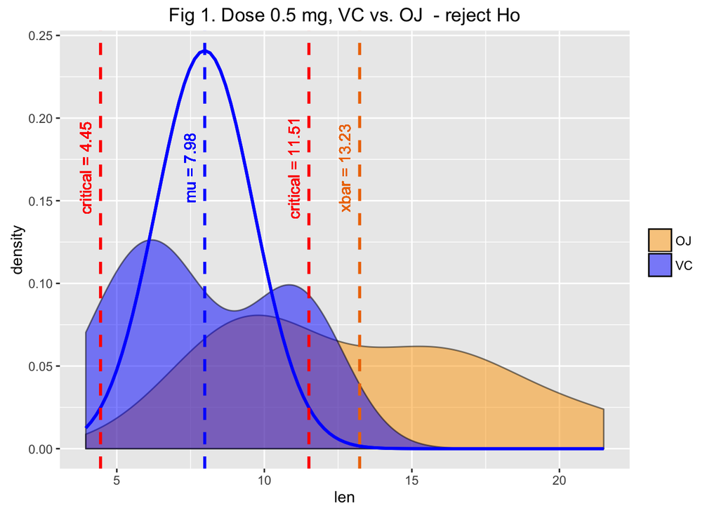

Let’s walk through the results visually:  
We plotted two density distributions (blue for VC and orange for OJ).  
We estimated t distribution by drawing the curve in solid blue, with mean=mu and std dev=std err.  
We added 4 dashed lines: blue as Ho mean, orange as Ha mean, and red as critical lines where we chop off the tails. Ho holds inside the red lines, Ho gets rejected outside the red lines. See Appendix B for R code on how we calculated the 4 lines.

We hope the visual result tells the story - the orange mean falls outside of the critical red lines, which makes us reject Ho and accept Ha. We’re 95% confident the alternative mean is not due to chance, but there’s still a 5% chance of type 1 error.

Dose 3 = 2 mg  
Step 4. Calculate 95% CIs using R t.test().

```
##                     [,1]    [,2]
## dose3.ci.t.test -3.79807 3.63807
## dose3.ci.manual -3.79807 3.63807
```

Step 5. Draw conclusions  
Based on the 95% CI, which does contain 0, we retain Ho and don’t have enough evidence to support Ha.  
Function t.test returns p-value: 0.9639, which is larger than alpha, and means that the difference in means is random. Our hypothetical researchers don’t have enough evidence against absorbic acid at 2 mg! They can use the p-value to confirm the results at any desired level of significance.

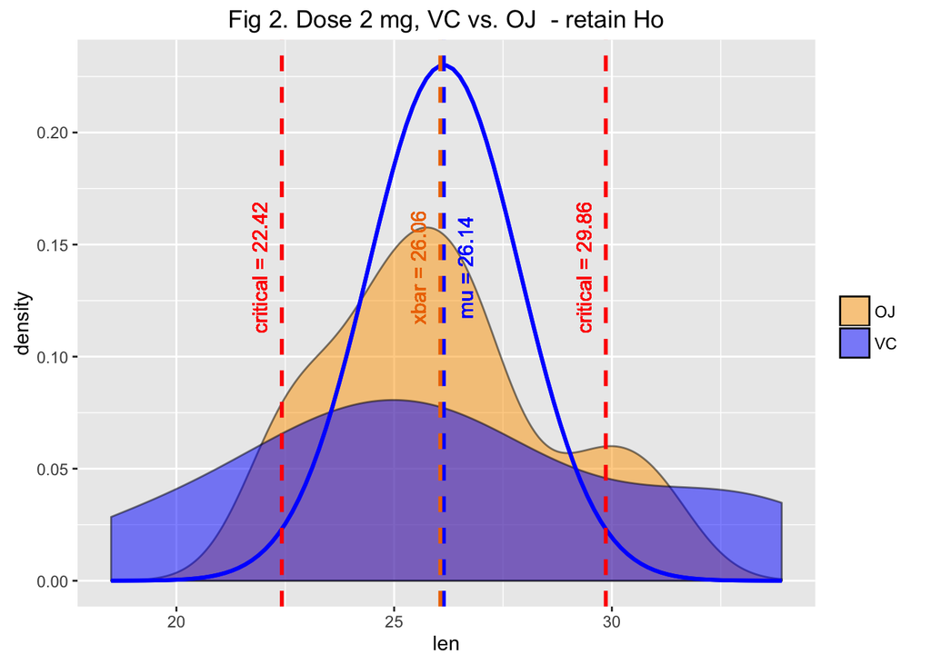

Let’s visually interpret our results again:  
We plotted two density distributions (blue for VC and orange for OJ).  
We estimated t distribution by drawing the curve in solid blue, with mean=mu and std dev=std err.  
We added 4 dashed lines: blue as Ho mean, orange as Ha mean, and red as critical lines where we chop off the tails. Ho holds inside the red lines, Ho gets rejected outside the red lines.

We hope the visual result tells the story - the orange mean is pretty close to the blue mean and quite far from the red lines. We retain Ho with 95% confindence about no difference between OJ vs VC, but still have 5% chance of type 2 error.